# HW5 Machine Learning

Devante Lee1

11/12/2020

```r
library(tidyverse)
library(factoextra)
library(caret)
library(flexclust)
library(cluster)
library(dplyr)
library(dendextend)
Cereals <-read.csv("C:/Users/Devante Lee/Downloads/Cereals.csv")
```

```r
Cereals2 <- Cereals[0:77,]
```

```r
rownames(Cereals2) <- c("All_Bran", "100%_Natural_Bran", "All-Bran", "All-Bran_with_Extra_Fiber",
                       "Almond_Delight", "Apple_Cinnamon_Cheerios", "Apple_Jacks", "Basic_4",
                  "Bran_Chex", "Bran_Flakes", "Cap'n'Crunch",  "Cheerios", "Cinnamon_Toast_Crunch",
                   "Clusters", "Cocoa_Puffs" , "Corn_Chex", "Corn_Flakes", "Corn_Pops", "Count_Chocula",
                  "Cracklin'_Oat_Bran", "Cream_of_Wheat_(Quick)", "Crispix", "Crispy_Wheat_&_Raisins", "Double_Chex",
                  "Froot_Loops", "Frosted_Flakes", "Frosted_Mini-Wheats", "Fruit_&_Fibre_Dates,_Walnuts,_and_Oats",
                  "Fruitful_Bran", "Fruity_Pebbles", "Golden_Crisp", "Golden_Grahams",  "Grape_Nuts_Flakes", "Grape-Nuts",
                  "Great_Grains_Pecan", "Honey_Graham_Ohs", "Honey_Nut_Cheerios", "Honey-comb",
                  "Just_Right_Crunchy__Nuggets", "Just_Right_Fruit_&_Nut", "Kix", "Life", "Lucky_Charms", "Maypo",
                  "Muesli_Raisins,_Dates,_&_Almonds", "Muesli_Raisins,_Peaches,_&_Pecans",
                  "Mueslix_Crispy_Blend", "Multi-Grain_Cheerios", "Nut&Honey_Crunch", "Nutri-Grain_Almond-Raisin",
                  "Nutri-grain_Wheat", "Oatmeal_Raisin_Crisp", "Post_Nat._Raisin_Bran", "Product_19",
                  "Puffed_Rice", "Puffed_Wheat", "Quaker_Oat_Squares", "Quaker_Oatmeal", "Raisin_Bran", "Raisin_Nut_Bran",
                  "Raisin_Squares", "Rice_Chex", "Rice_Krispies", "Shredded_Wheat",
                  "Shredded_Wheat_'n'Bran", "Shredded_Wheat_spoon_size", "Smacks", "Special_K",
                  "Strawberry_Fruit_Wheats", "Total_Corn_Flakes",  "Total_Raisin_Bran", "Total_Whole_Grain",
                  "Triples", "Trix", "Wheat_Chex", "Wheaties", "Wheaties_Honey_Gold"
                  )
```

```r
Cerealsdata <- Cereals2[,4:16]
```

```r
scale(Cerealsdata)
```

```
##                                          calories    protein         fat
## All_Bran                               -1.8929836  1.3286071 -0.01290349
## 100%_Natural_Bran                       0.6732089  0.4151897  3.96137277
## All-Bran                               -1.8929836  1.3286071 -0.01290349
## All-Bran_with_Extra_Fiber              -2.9194605  1.3286071 -1.00647256
## Almond_Delight                          0.1599704 -0.4982277  0.98066557
## Apple_Cinnamon_Cheerios                 0.1599704 -0.4982277  0.98066557
## Apple_Jacks                             0.1599704 -0.4982277 -1.00647256
## Basic_4                                 1.1864474  0.4151897  0.98066557
## Bran_Chex                              -0.8665066 -0.4982277 -0.01290349
## Bran_Flakes                            -0.8665066  0.4151897 -1.00647256
## Cap'n'Crunch                            0.6732089 -1.4116451  0.98066557
## Cheerios                                0.1599704  3.1554419  0.98066557
## Cinnamon_Toast_Crunch                   0.6732089 -1.4116451  1.97423464
## Clusters                                0.1599704  0.4151897  0.98066557
## Cocoa_Puffs                             0.1599704 -1.4116451 -0.01290349
## Corn_Chex                               0.1599704 -0.4982277 -1.00647256
## Corn_Flakes                            -0.3532681 -0.4982277 -1.00647256
## Corn_Pops                               0.1599704 -1.4116451 -1.00647256
## Count_Chocula                           0.1599704 -1.4116451 -0.01290349
## Cracklin'_Oat_Bran                      0.1599704  0.4151897  1.97423464
## Cream_of_Wheat_(Quick)                 -0.3532681  0.4151897 -1.00647256
## Crispix                                 0.1599704 -0.4982277 -1.00647256
## Crispy_Wheat_&_Raisins                 -0.3532681 -0.4982277 -0.01290349
## Double_Chex                            -0.3532681 -0.4982277 -1.00647256
## Froot_Loops                             0.1599704 -0.4982277 -0.01290349
## Frosted_Flakes                          0.1599704 -1.4116451 -1.00647256
## Frosted_Mini-Wheats                    -0.3532681  0.4151897 -1.00647256
## Fruit_&_Fibre_Dates,_Walnuts,_and_Oats  0.6732089  0.4151897  0.98066557
## Fruitful_Bran                           0.6732089  0.4151897 -1.00647256
## Fruity_Pebbles                          0.1599704 -1.4116451 -0.01290349
## Golden_Crisp                           -0.3532681 -0.4982277 -1.00647256
## Golden_Grahams                          0.1599704 -1.4116451 -0.01290349
## Grape_Nuts_Flakes                      -0.3532681  0.4151897 -0.01290349
## Grape-Nuts                              0.1599704  0.4151897 -1.00647256
## Great_Grains_Pecan                      0.6732089  0.4151897  1.97423464
## Honey_Graham_Ohs                        0.6732089 -1.4116451  0.98066557
## Honey_Nut_Cheerios                      0.1599704  0.4151897 -0.01290349
## Honey-comb                              0.1599704 -1.4116451 -1.00647256
## Just_Right_Crunchy__Nuggets             0.1599704 -0.4982277 -0.01290349
```

[output cut: 345 more lines]

```
## Triples                                -0.25339630
## Trix                                   -1.06158592
## Wheat_Chex                              0.50698324
## Wheaties                                0.63545985
## Wheaties_Honey_Gold                    -0.46116700
## attr(,"scaled:center")
##   calories    protein        fat     sodium      fiber      carbo     sugars
## 106.883117   2.545455   1.012987 159.675325   2.151948  14.802632   7.026316
##     potass   vitamins      shelf     weight       cups     rating
##  98.666667  28.246753   2.207792   1.029610   0.821039  42.665705
## attr(,"scaled:scale")
##   calories    protein        fat     sodium      fiber      carbo     sugars
## 19.4841191  1.0947897  1.0064726 83.8322952  2.3833640  3.9073256  4.3786564
##     potass   vitamins      shelf     weight       cups     rating
## 70.4106360 22.3425225  0.8325241  0.1504768  0.2327161 14.0472887
```

```r
Cereals1 <- na.omit(Cerealsdata)
```

[figure not shown]

```r
d <- dist(Cereals1, method = "euclidean")
hc <- hclust(d, method = "complete")
plot(hc)
rect.hclust(hc, k= 6 , border = 1:6)
```

While comparing the differences between the euclidean distance and the hierarchical clustering it is pretty obvious to see data being swithed around to different areas.It is showing for the most part that the cereals didn’t completely change clusters. The differences came mostly in the location of the cluster placement and not the switching. If I was to keep the clusters at a height of 150 there would essentially be very minimal change. If I moved my cluster criteria to 100 there would be mass changes in every cluster that has been created.

```r
Cereals1single <- agnes(Cereals1, method = "single")
Cereals1complete <- agnes(Cereals1, method = "complete")
Cereals1average <- agnes(Cereals1, method = "average")
Cereals1ward <- agnes(Cereals1, method = "ward")
```

```r
print(Cereals1single$ac)
```

```
## [1] 0.7311616
```

```r
print(Cereals1complete$ac)
```

```
## [1] 0.922957
```

```r
print(Cereals1average$ac)
```

```
## [1] 0.8792621
```

```r
print(Cereals1ward$ac)
```

```
## [1] 0.9597071
```

Best linkage method == Cereals1ward

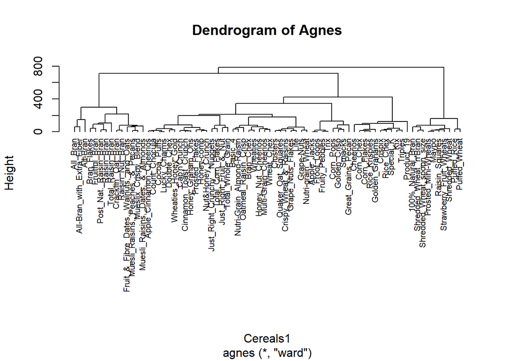

```r
pltree(Cereals1ward, cex = 0.7, hang = -1, main = "Dendrogram of Agnes")
```

Hierarchical clustering doesn’t handle big data the way that kmeans clustering can. This quite possibly the biggest downfall of using hierarchical clustering over kmeans

I would choose six clusters

```r
PartitionA <- Cereals1[1:38,]
PartitionA1ward <- agnes(PartitionA, method = "ward")
```

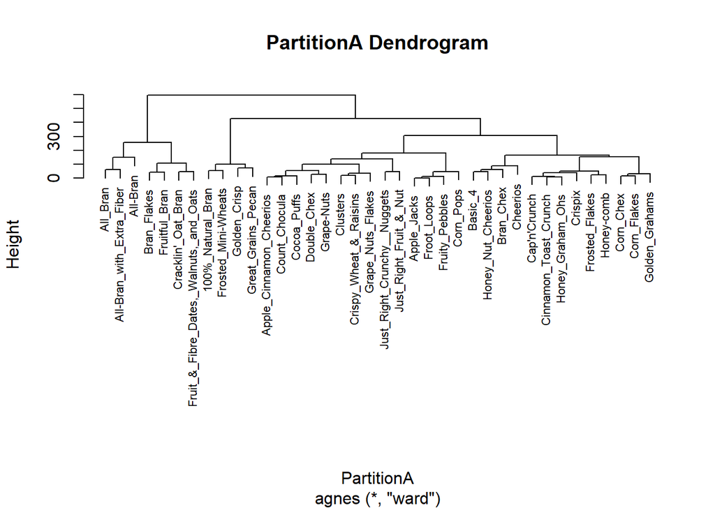

```r
pltree(PartitionA1ward, cex =0.7, main = "PartitionA Dendrogram")
```

```r
PartitionB <- Cereals1[40:74,]
PartitionB
```

```
##                                   calories protein fat sodium fiber carbo
## Life                                   100       4   2    150   2.0  12.0
## Lucky_Charms                           110       2   1    180   0.0  12.0
## Maypo                                  100       4   1      0   0.0  16.0
## Muesli_Raisins,_Dates,_&_Almonds       150       4   3     95   3.0  16.0
## Muesli_Raisins,_Peaches,_&_Pecans      150       4   3    150   3.0  16.0
## Mueslix_Crispy_Blend                   160       3   2    150   3.0  17.0
## Multi-Grain_Cheerios                   100       2   1    220   2.0  15.0
## Nut&Honey_Crunch                       120       2   1    190   0.0  15.0
## Nutri-Grain_Almond-Raisin              140       3   2    220   3.0  21.0
## Nutri-grain_Wheat                       90       3   0    170   3.0  18.0
## Oatmeal_Raisin_Crisp                   130       3   2    170   1.5  13.5
## Post_Nat._Raisin_Bran                  120       3   1    200   6.0  11.0
## Product_19                             100       3   0    320   1.0  20.0
## Puffed_Rice                             50       1   0      0   0.0  13.0
## Puffed_Wheat                            50       2   0      0   1.0  10.0
## Quaker_Oat_Squares                     100       4   1    135   2.0  14.0
## Raisin_Bran                            120       3   1    210   5.0  14.0
## Raisin_Nut_Bran                        100       3   2    140   2.5  10.5
## Raisin_Squares                          90       2   0      0   2.0  15.0
## Rice_Chex                              110       1   0    240   0.0  23.0
## Rice_Krispies                          110       2   0    290   0.0  22.0
## Shredded_Wheat                          80       2   0      0   3.0  16.0
## Shredded_Wheat_'n'Bran                  90       3   0      0   4.0  19.0
## Shredded_Wheat_spoon_size               90       3   0      0   3.0  20.0
## Smacks                                 110       2   1     70   1.0   9.0
## Special_K                              110       6   0    230   1.0  16.0
## Strawberry_Fruit_Wheats                 90       2   0     15   3.0  15.0
## Total_Corn_Flakes                      110       2   1    200   0.0  21.0
## Total_Raisin_Bran                      140       3   1    190   4.0  15.0
## Total_Whole_Grain                      100       3   1    200   3.0  16.0
## Triples                                110       2   1    250   0.0  21.0
## Trix                                   110       1   1    140   0.0  13.0
## Wheat_Chex                             100       3   1    230   3.0  17.0
## Wheaties                               100       3   1    200   3.0  17.0
## Wheaties_Honey_Gold                    110       2   1    200   1.0  16.0
##                                   sugars potass vitamins shelf weight cups
## Life                                   6     95       25     2   1.00 0.67
## Lucky_Charms                          12     55       25     2   1.00 1.00
## Maypo                                  3     95       25     2   1.00 1.00
```

[output cut: 53 more lines]

```
## Rice_Krispies                     40.56016
## Shredded_Wheat                    68.23588
## Shredded_Wheat_'n'Bran            74.47295
## Shredded_Wheat_spoon_size         72.80179
## Smacks                            31.23005
## Special_K                         53.13132
## Strawberry_Fruit_Wheats           59.36399
## Total_Corn_Flakes                 38.83975
## Total_Raisin_Bran                 28.59278
## Total_Whole_Grain                 46.65884
## Triples                           39.10617
## Trix                              27.75330
## Wheat_Chex                        49.78744
## Wheaties                          51.59219
## Wheaties_Honey_Gold               36.18756
```

```r
PartitionB1ward <- agnes(PartitionB, method = "ward")
```

```r
view(PartitionB)
```

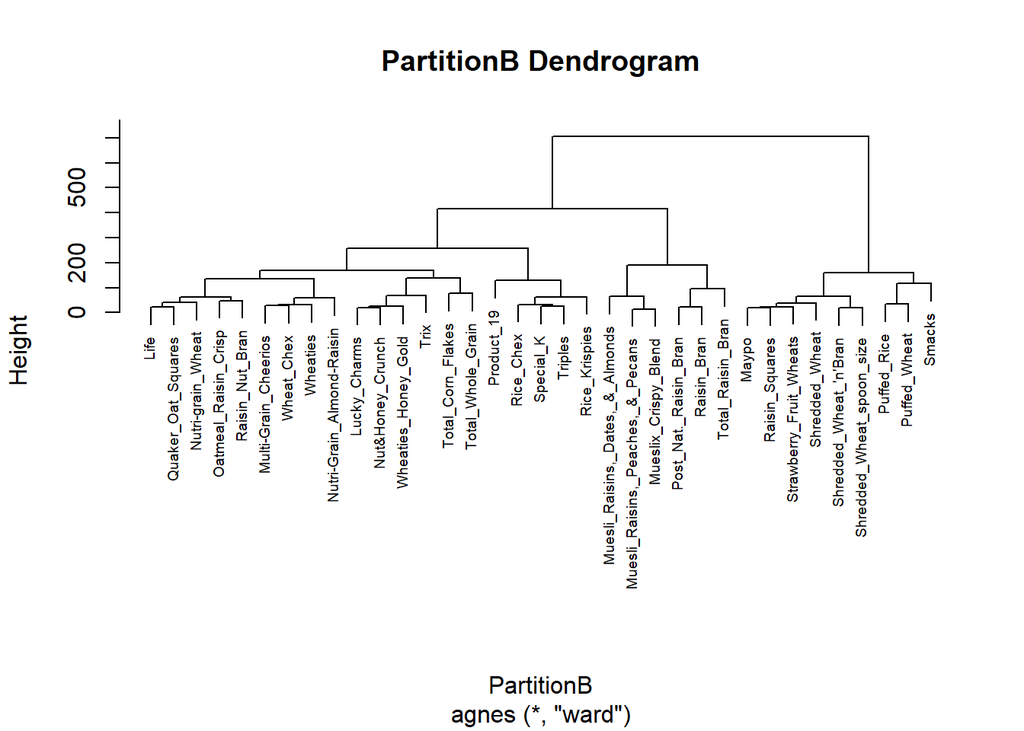

```r
pltree(PartitionB1ward, cex = 0.6, main = "PartitionB Dendrogram")
```

```r
set.seed(222)

Cer <- kmeans(Cereals1, centers = 6, nstart = 20)

Cer$centers
```

```
##   calories  protein       fat   sodium     fiber    carbo    sugars    potass
## 1 109.5833 2.250000 1.0416667 189.1667 1.6041667 15.64583  7.125000  77.50000
## 2 110.0000 2.428571 0.7142857 260.0000 0.6071429 18.17857  4.857143  48.21429
## 3 123.0000 3.200000 2.1000000 142.0000 2.8000000 13.30000  9.300000 145.50000
## 4  97.5000 3.375000 0.6250000 197.5000 7.2500000 10.87500  8.500000 255.00000
## 5 110.0000 1.750000 0.8750000 100.6250 0.8750000 11.75000 12.125000  38.75000
## 6  86.0000 2.500000 0.6000000   3.0000 2.1000000 14.60000  2.900000  95.00000
##   vitamins    shelf  weight      cups   rating
## 1 37.50000 2.083333 1.04000 0.8358333 38.71129
## 2 30.35714 1.714286 1.00000 0.9914286 38.23576
## 3 25.00000 3.000000 1.10000 0.6590000 37.91983
## 4 34.37500 2.875000 1.18625 0.6150000 52.69441
## 5 25.00000 2.000000 1.00000 0.8387500 33.65472
## 6 10.00000 2.100000 0.88300 0.8640000 60.11493
```

```r
clust1 <- Cer$centers[,1]
clust2 <- Cer$centers[,2]
clust3 <- Cer$centers[,3]
clust4 <- Cer$centers[,4]
clust5 <- Cer$centers[,5]
clust6 <- Cer$centers[,6]
```

```r
Clust1and2 <- rbind(clust1, clust2)

dist(Clust1and2, method = "euclidean")
```

```
##          clust1
## clust2 254.9391
```

```r
Clust3and4 <- rbind(clust3, clust4)

dist(Clust3and4, method = "euclidean")
```

```
##          clust3
## clust4 413.4098
```

```r
Clust5and6 <- rbind(clust5, clust6)

dist(Clust5and6, method = "euclidean")
```

```
##          clust5
## clust6 30.06376
```

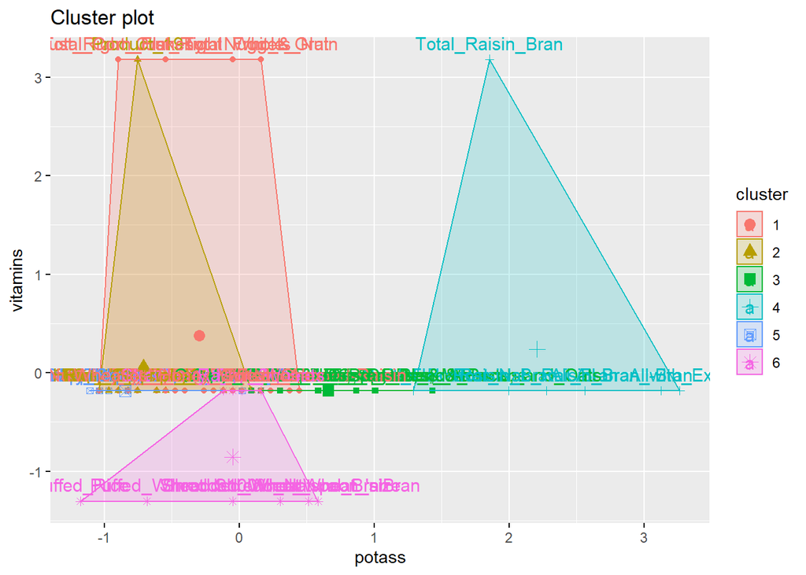

```r
fviz_cluster(Cer, data = Cereals1[,8:9])
```

```r
Healthycereals <- Cereals %>%
  select(name, fiber, protein, potass, vitamins)
Healthycereals
```

```
##                                      name fiber protein potass vitamins
## 1                               100%_Bran  10.0       4    280       25
## 2                       100%_Natural_Bran   2.0       3    135        0
## 3                                All-Bran   9.0       4    320       25
## 4               All-Bran_with_Extra_Fiber  14.0       4    330       25
## 5                          Almond_Delight   1.0       2     NA       25
## 6                 Apple_Cinnamon_Cheerios   1.5       2     70       25
## 7                             Apple_Jacks   1.0       2     30       25
## 8                                 Basic_4   2.0       3    100       25
## 9                               Bran_Chex   4.0       2    125       25
## 10                            Bran_Flakes   5.0       3    190       25
## 11                           Cap'n'Crunch   0.0       1     35       25
## 12                               Cheerios   2.0       6    105       25
## 13                  Cinnamon_Toast_Crunch   0.0       1     45       25
## 14                               Clusters   2.0       3    105       25
```

[output cut: 63 more lines]

```r
Allcereals <- na.omit(Healthycereals)
Allcereals <- agnes(Allcereals, method = "ward")
```

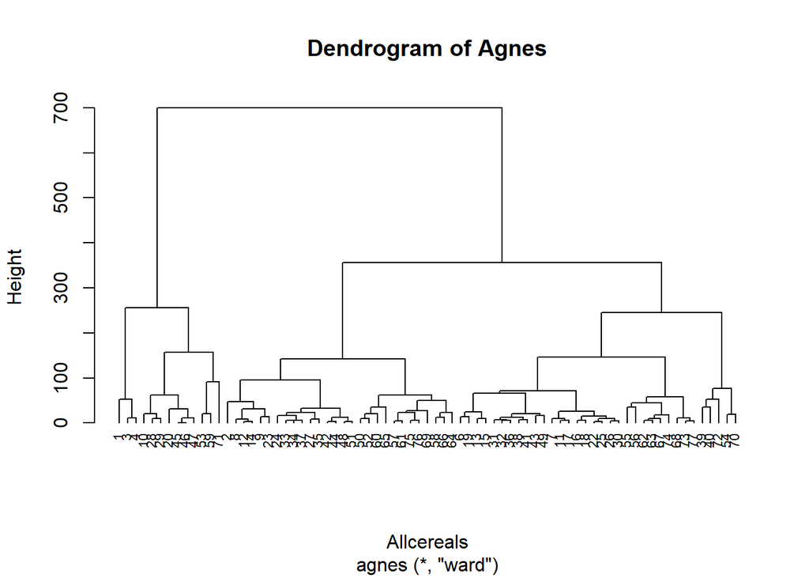

```r
pltree(Allcereals, cex = 0.7, hang = -1, main = "Dendrogram of Agnes")
```

When looking at both Hierarchical clustering and kmeans there are differences that definitely make them preferred methods of usage in different situations. When looking into comparing both HC and Kmeans the distance needs to be quantifiable in both cases in order for the algorithm to work. This is one of the firm similarities amoung both clustering methods. When dealing with smaller data sets you would mostly rely on hierarchical clustering over kmeans clustering. In opposite situations it is pertinent to use Kmeans clustering on larger data sets.Kmeans clustering has been widely thought of as a much more scaleable clustering algorithm than hierarchical clustering. A pro of using hierarchical clustering is that it is much easier for you decipher results than in Kmeans. Kmeans is much more time consuming, which would make sense as it is the preferred usage in many cases for larger datasets. HC allows for us to better view how many clusters we should have after the dendrogram has been created. When using the kmeans algorithm it is very important to already have an idea of how many clusters you will be using before you have created the algorithm its self. The usage of Kmeans clustering would be more cost intensive and time consuming when be used, but it would be the preffered method when working on much larger sets of data. Hierarchical Clustering provides a better visual in many cases, but the data must be smaller in order to be effective and determine strategies from what you have recovered.